```
Ecole Centrale Nantes
Option InfoIA
PAPY: Programmation avancée python
TP3.1 Application du cours
Année 2023-2024
Auteur: Lucas Lestandi
lucas.lestandi@ec-nantes.fr
V1.1
```

# Application directe du cours

**Durée 2h**

**Objectifs:** Mise en application de quelques libraries

- numpy
- matplotlib
- scipy

```python
import numpy as np
import matplotlib.pyplot as plt
```

## Pour se convaincre de l'efficacité de numpy

**Exercice :** On veut initialiser un tableau d'entiers allant de 1 à N, puis en calculer la somme. On pourra tester avec $N=10^6$ et `%%timeit` pour avoir une estimation stable du temps de calcul. Proposer 3 implémentations: 1)avec boucle for, 2) par compréhension, 3) avec numpy.  
Que peut-on dire de la vitesse d'exécution?  
Si l'on veut uniquement le résultat, on peut aussi se passer de l'initialisation de la liste (et donc de son cout mémoire). Qu'en est-il du temps de calcul?

```python
%%timeit
# initialiser un tableau d'entiers de 1 à N
N = 10**6
# t = [i for i in range(1, N+1)]
t_boucle =[]
for i in range(1, N+1):
    t_boucle.append(i)
```

```
29.4 ms ± 890 µs per loop (mean ± std. dev. of 7 runs, 10 loops each)
```

```python
%%timeit
import numpy as np
N = 10**6
t_np = np.arange(N+1)
```

```
1.07 ms ± 74.1 µs per loop (mean ± std. dev. of 7 runs, 1,000 loops each)
```

```python
%%timeit
N = 10**6
t_com = [i for i in range(N+1)]
```

```
26.2 ms ± 1.01 ms per loop (mean ± std. dev. of 7 runs, 10 loops each)
```

## linalg : fonction basique

**Exercice :** Calculer le déterminant et l'inverse de la matrice suivante. On vérifiera la qualité du calcul en calculant $||AA^{-1}-I||$. Comment améliorer le résultat? Suggestion: googler "conditionnement". $$ \left(\begin{array}{cc} 1 & 2 & 3\\ 0 & 5 & -4\\ -1 & 8 & -11.0000000001\\ \end{array}\right) $$

Calculer le déterminant et l'inverse de la matrice suivante. On vérifiera la qualité du calcul en calculant $||AA^{-1}-I||$. Comment améliorer le résultat? Suggestion: googler "conditionnement". $$ \left(\begin{array}{cc} 1 & 2 & 3\\ 0 & 5 & -4\\ -1 & 8 & -11.0000000001\\ \end{array}\right) $$

```python
import numpy as np
A = np.array([[1, 2, 3],
             [0, 5, -4],
             [-1, 8, -11.0000000001]])
A_inv = np.linalg.inv(A)
A_det = np.linalg.det(A)
I = np.eye(3)
eq = np.dot(A, A_inv) - I
eq_det = np.linalg.det(eq)
# Utiliser des bibliothèques de calculs numériques de haute précision

# Régularisation
```

## Calcul des décimales de $\pi$

**Exercice :** Ecrire une programme qui calcule les décimales de $\pi$ par la méthode de Monte-Carlo. Le raisonnement est le suivant.  
La surface d'un cercle est $S=\pi r^2$, ainsi, pour calculer $\pi$ il suffit d'évaluer la surface d'un cercle de rayon $r$ connu. Pour plus de simplicité, on choisit $r=1$ et on restreint le domaine au quart de cercle centré dans le coin carré de coté 1. C'est ici qu'intervient la méthode de Monte-Carlo, on va tirer au hasard des points dans ce carré. et compter ceux qui sont à l'intérieur du cercle. Pour un grand nombre de points, on obtient un bonne estimation de $\pi=\frac{pts \; intérieur}{pts \; extrieurs} \times 4$.  
On affichera un graphe montrant l'évaluation, similaire à celui-ci pour illustrer la méthodes avec 50 points:

[figure not shown]

Et on observera la convergence de notre évaluation avec le graphe suivant. On fera attention à ne pas recalculer un nouveau cas pour chaque valeur de N.

[figure not shown]

Mais on ne voit finalement pas grand chose sur le graphe, le suivant, en base logarithmique de l'erreur est beaucoup plus parlant:

[figure not shown]

Enfin, on évaluera la variabilité de la méthode avec une petite étude statistique pour $N=10^4$ et $N=10^6$.

| N | Valeur moyenne | Sigma | Nombre de tests |
| --- | --- | --- | --- |
| 10 000 | 3.1423039999999998 | 0.014777184576231025 | 50 |
| $10^6$ | 3.1411283199999995 | 0.001587272546729095 | 50 |

Ecrire une programme qui calcule les décimales de $\pi$ par la méthode de Monte-Carlo. Le raisonnement est le suivant.  
La surface d'un cercle est $S=\pi r^2$, ainsi, pour calculer $\pi$ il suffit d'évaluer la surface d'un cercle de rayon $r$ connu. Pour plus de simplicité, on choisit $r=1$ et on restreint le domaine au quart de cercle centré dans le coin carré de coté 1. C'est ici qu'intervient la méthode de Monte-Carlo, on va tirer au hasard des points dans ce carré. et compter ceux qui sont à l'intérieur du cercle. Pour un grand nombre de points, on obtient un bonne estimation de $\pi=\frac{pts \; intérieur}{pts \; extrieurs} \times 4$.

```python
import random
# definir le rayon
r = 1.0
# npmbre d'échantionllage
num_sample = 10000
# points interieur
count = 0
for i in range(num_sample):
    x = random.uniform(0, r)
    y = random.uniform(0, r)
    if x**2 + y**2 <= r**2:
        count += 1
# calculer
pi = count / num_sample * 4

print(pi)
```

```
3.1248
```

## Manipulation d'images

**ExerciceManipulation d'image :** On utilise ici scipy pour charger une image RGB dans un array à 3 dimensions (vertical, horizontal, couleur). Matplotlib permet de visualiser très facilement grace à imshow.

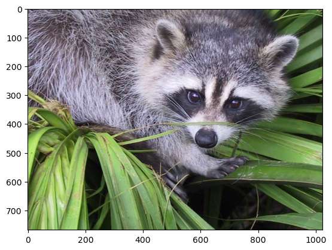

```python
from scipy import misc
f = misc.face()

import matplotlib.pyplot as plt
plt.imshow(f)
plt.show()
```

**Exercice Manipulation d'image :** Quelle est la dimension de l'image? Afficher les canaux un par un.

```python
# obtenir la dimension de l'image
height, width, channel = f.shape
print(f"height: {height}, width: {width}, channel: {channel}")

# separer les canaux
red_channel = f[:, :, 0]
green_channel = f[:, :, 1]
blue_channel = f[:, :, 2]

print(f"red_chennel: \n{red_channel}\ngreen_channel: \n{green_channel}\nblue_channel: \n{blue_channel}")
```

```
height: 768, width: 1024, channel: 3
red_chennel:
[[121 138 153 ... 119 131 139]
 [ 89 110 130 ... 118 134 146]
 [ 73  94 115 ... 117 133 144]
 ...
 [ 87  94 107 ... 120 119 119]
 [ 85  95 112 ... 121 120 120]
 [ 85  97 111 ... 120 119 118]]
green_channel:
[[112 129 144 ... 126 136 144]
 [ 82 103 122 ... 125 141 153]
 [ 66  87 108 ... 126 142 153]
 ...
 [106 110 124 ... 158 157 158]
 [101 111 127 ... 157 156 156]
 [101 113 126 ... 156 155 154]]
blue_channel:
[[131 148 165 ...  74  82  90]
 [100 121 143 ...  71  87  99]
 [ 84 105 126 ...  71  87  98]
 ...
 [ 76  81  92 ...  97  96  95]
 [ 72  82  96 ...  96  94  94]
 [ 74  84  97 ...  95  93  92]]
```

**Exercice Manipulation d'image :** Afficher l'image en noir et blanc.

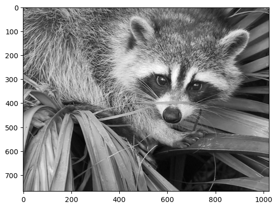

```python
gray_array = np.array([0.299, 0.587, 0.144])
gray_image = np.dot(f, gray_array)
plt.imshow(gray_image, cmap="gray")
plt.show()
```

**Exercice Manipulation d'image :** Créer un version noir et blanc de f si ce n'est déjà fait puis l'afficher en sautant une ligne sur deux. Que se passe-t-il? De même, afficher l'image en miroire.

[output not shown]

[output cut: 329 more lines]

[output not shown]

[figure not shown]

```python
# height
l = len(gray_image)

new_gray_image = [[]]

for i in range(0, l, 2):
    print(gray_image[i])
    if i == 0:
        new_gray_image = [gray_image[0]]
    else:
        new_gray_image = np.vstack((new_gray_image, gray_image[i]))

plt.imshow(new_gray_image)
plt.show()
```

**Exercice Manipulation d'image :** Créer un masque circulaire pour rendre noir tous les pixels en dehors du cercle.

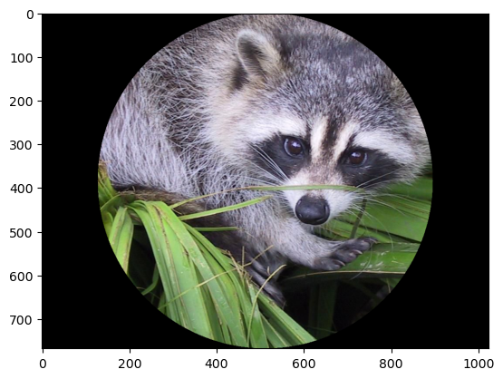

```python
# creer un masque circulaire noir
mask = np.ones((height, width), dtype=np.uint8) * 255

# definir les milieux
center_x = width // 2
center_y = height // 2
radius = min(center_x, center_y)

# peintre un masque
y, x = np.ogrid[:height, :width]
mask[((x - center_x) ** 2 + (y -center_y) ** 2) > radius ** 2] = 0

# appliquer le masque
masked_image = f.copy()

masked_image[np.stack([mask]*3, axis=-1) == 0] = 0

plt.imshow(masked_image)
plt.show()
```

**Exercice Manipulation d'image :** Créer une version binaire (blanc en dessous, noir au dessus du seuil) de l'image avec la valeur limite de votre choix.

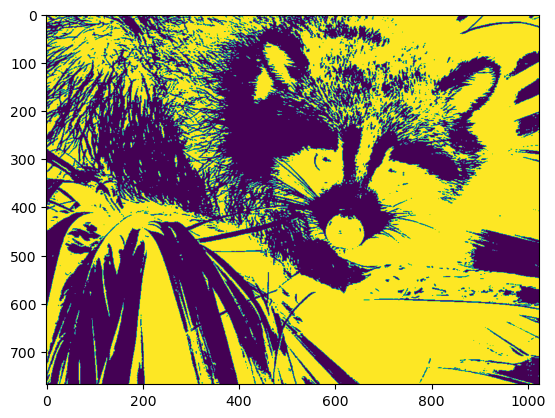

```python
# definir le seuil
seuil = 128
# creer une matrix binaire
binary_image = np.where(gray_image > seuil, 0, 255)

plt.imshow(binary_image)
plt.show()
```

**Exercice Manipulation d'image :** Calculer le gradient de cette image et l'afficher. On pourra se contenter d'un calcul au premier ordre avec les voisins direct.
$$ ||\nabla p_{ij}||= \sqrt{(p_{i+1j}-p_{i+1j})^2+(p_{ij+1}-p_{ij+1})^2}$$ que l'on pourra, au besoin normaliser. Comparer avec les méthodes des librairies de traitement d'image telle `ndime,openCV,PIL` et en particulier le filtre de Sobel.

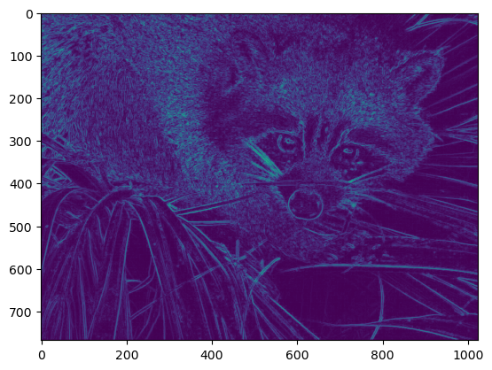

```python
import math
grad_image = np.ones((height, width), dtype=np.uint8)
for i in range(height-1):
    for j in range(width-1):
        grad_image[i][j] = math.sqrt((gray_image[i+1][j] - gray_image[i][j])**2 + (gray_image[i][j+1] - gray_image[i][j])**2)

plt.imshow(grad_image)
plt.show()
```

## Le jeux de la vie

**Exercice long :** Le Jeu de la vie est un automate cellulaire imaginé par John Horton Conway en 1970. Malgré des règles très simples, il est Turing-complet. C'est un jeu de simulation au sens mathématique.  
Lire le reste de la présentation [wikipedia](https://fr.wikipedia.org/wiki/Jeu_de_la_vie).  
Programmer une version simple avec numpy et matplotlib. On pourra se satisfaire d'un tableau stockant toute la grille et d'une fonction qui avance le temps (en suivant les règles, bien-sûr).

```python
import matplotlib.pyplot as plt
import matplotlib.animation as animation
import numpy as np

# etat 0-mort, 1-vivant

# nombre actuel de cellules vivantes dans son voisinage

def random_initial_state(width: int, height: int):
    return np.random.choice([0, 1], size=(height, width))

def next_state(current_state):
    height, width = current_state.shape
    new_state = np.zeros((height, width))
    for i in range(height):
        for j in range(width):
            # calculer le nombre de voisinage
            min_i = max(i-1, 0)
            max_i = min(i+1, height-1)
            min_j = max(0, j-1)
            max_j = min(width-1, j+1)
            neighbors = current_state[min_i-1 : max_i + 2, min_j-1 : max_j + 2]
            alive_neighbors = np.sum(neighbors) - current_state[i, j]
            if current_state[i, j] == 1 and (alive_neighbors == 2 or 3):
                new_state[i, j] = 1
            elif current_state[i, j ] == 0 and alive_neighbors == 3:
                new_state[i, j] = 1
            else:
                new_state[i, j] = 0
    return new_state

def create_animation(initial_state, generations):
    fig, ax = plt.subplots()
    im = ax.imshow(initial_state, cmap='binary', animated=True)

    ims = []

    current_state = initial_state
    for g in range(generations):
        im.set_data(current_state)
        ax.set_title(f'Generation {g + 1}')
        ims.append([im])
        current_state = next_state(current_state)
        fig.canvas.draw()

    ani = animation.ArtistAnimation(fig, ims, interval=200, blit=True)
    plt.show()


if __name__ == '__main__':
    width, height = 50, 50
    initial_state = random_initial_state(width, height)
    generations = 100
    create_animation(initial_state, generations)
```

```python
#!/usr/bin/env python3

"""SmoothLife -- Conway's GoL in continuous space

Re-written in Python using the speedups of Numpy

Notes on porting:
    Raffler's original paper uses M to represent the inner cell area
    and N to represent the outer cell area.

    `BasicRules` is simplified and has some good comments.
    `ExtensiveRules` is much more extensive but a little harder to follow.

Thank you to tscheepers for:
    Fixing the initialization in add_speckles to be better at scaling.
    Figuring out the rules and transition function that work with smooth timesteps.

Todo:
    Fancy UI
    Refactor. OO design always fails because of nested variable access

Explanations and code (in other language) here:
https://arxiv.org/pdf/1111.1567.pdf
https://0fps.net/2012/11/19/conways-game-of-life-for-curved-surfaces-part-1/
https://jsfiddle.net/mikola/aj2vq/
https://www.youtube.com/watch?v=KJe9H6qS82I
https://sourceforge.net/projects/smoothlife/
"""

import math

import numpy as np
from matplotlib import pyplot as plt
from matplotlib import animation

# # Necessary for writing video
# from skvideo.io import FFmpegWriter
# from matplotlib import cm


def logistic_threshold(x, x0, alpha):
    """Logistic function on x around x0 with transition width alpha

    Approximately:
        (x - alpha/2) < x0 : 0
        (x + alpha/2) > x0 : 1

    AKA snm2D.frag:func_smooth
    """
    return 1.0 / (1.0 + np.exp(-4.0 / alpha * (x - x0)))


def hard_threshold(x, x0):
    """x > x0 : 1 ? 0

    AKA snm2D.frag:func_hard
    """
    return np.greater(x, x0)


def linearized_threshold(x, x0, alpha):
    """Threshold x around x0 with a linear transition region alpha

    AKA snm2D.frag:func_linear
    """
    return np.clip((x - x0) / alpha + 0.5, 0, 1)


def logistic_interval(x, a, b, alpha):
    """Logistic function on x between a and b with transition width alpha

    Very approximately:
        x < a     : 0
        a < x < b : 1
        x > b     : 0

    AKA snm2D.frag:sigmoid_ab with sigtype==4
    """
    return logistic_threshold(x, a, alpha) * (1.0 - logistic_threshold(x, b, alpha))


def linearized_interval(x, a, b, alpha):
    """Function a<x<b with linearized threshold regions

    Very approximately:
        x < a     : 0
        a < x < b : 1
        x > b     : 0

    AKA snm2D.frag:sigmoid_ab with sigtype==1
    """
    return linearized_threshold(x, a, alpha) * (1.0 - linearized_threshold(x, b, alpha))


def lerp(a, b, t):
    """Linear intererpolate from a to b with t ranging [0,1]

    AKA: OpenGL mix
    """
    return (1.0 - t) * a + t * b


class BasicRules:
    # Birth range
    B1 = 0.278
    B2 = 0.365

    # Survival range
    D1 = 0.267
    D2 = 0.445

    # Sigmoid widths
    N = 0.028
    M = 0.147

    def __init__(self, **kwargs):
        for k, v in kwargs.items():
            if hasattr(self, k):
                setattr(self, k, v)
            else:
                raise ValueError("Unexpected attribute %s" % k)

    def clear(self):
        pass

    def s(self, n, m, field):
        """State transition function

        This corresponds to SmoothLifeSDL with:
            sigmode: 4
            sigtype: 4
            mixtype: 4
        """
        # Convert the local cell average `m` to a metric of how alive the local cell is.
        # We transition around 0.5 (0 is fully dead and 1 is fully alive).
        # The transition width is set by `self.M`
        aliveness = logistic_threshold(m, 0.5, self.M)
        # A fully dead cell will become alive if the neighbor density is between B1 and B2.
        # A fully alive cell will stay alive if the neighhbor density is between D1 and D2.
        # Interpolate between the two sets of thresholds depending on how alive/dead the cell is.
        threshold1 = lerp(self.B1, self.D1, aliveness)
        threshold2 = lerp(self.B2, self.D2, aliveness)
        # Now with the smoothness of `logistic_interval` determine if the neighbor density is
        # inside of the threshold to stay/become alive.
        new_aliveness = logistic_interval(n, threshold1, threshold2, self.N)

        return np.clip(new_aliveness, 0, 1)


class ExtensiveRules(BasicRules):
    """Rules from Rafler's SmoothLifeSDL snm2D.frag"""

    sigmode = 0
    sigtype = 0
    mixtype = 0

    timestep_mode = 0
    dt = 0.1

    # History for timestep_mode 5
    esses = [None] * 3
    esses_count = 0

    def sigmoid_ab(self, x, a, b):
        if self.sigtype == 0:
            return hard_threshold(x, a) * (1 - hard_threshold(x, b))
        elif self.sigtype == 1:
            return linearized_interval(x, a, b, self.N)
        elif self.sigtype == 4:
            return logistic_interval(x, a, b, self.N)
        else:
            raise NotImplementedError

    def sigmoid_mix(self, x, y, m):
        if self.mixtype == 0:
            intermediate = hard_threshold(m, 0.5)
        elif self.mixtype == 1:
            intermediate = linearized_threshold(m, 0.5, self.M)
        elif self.mixtype == 4:
            intermediate = logistic_threshold(m, 0.5, self.M)
        else:
            raise NotImplementedError
        return lerp(x, y, intermediate)

    def clear(self):
        self.esses = [None] * 3
        self.esses_count = 0

    def s(self, n, m, field):
        if self.sigmode == 1:
            b_thresh = self.sigmoid_ab(n, self.B1, self.B2)
            d_thresh = self.sigmoid_ab(n, self.D1, self.D2)
            transition = lerp(b_thresh, d_thresh, m)
        elif self.sigmode == 2:
            b_thresh = self.sigmoid_ab(n, self.B1, self.B2)
            d_thresh = self.sigmoid_ab(n, self.D1, self.D2)
            transition = self.sigmoid_mix(b_thresh, d_thresh, m)
        elif self.sigmode == 3:
            threshold1 = lerp(self.B1, self.D1, m)
            threshold2 = lerp(self.B2, self.D2, m)
            transition = self.sigmoid_ab(n, threshold1, threshold2)
        elif self.sigmode == 4:
            threshold1 = self.sigmoid_mix(self.B1, self.D1, m)
            threshold2 = self.sigmoid_mix(self.B2, self.D2, m)
            transition = self.sigmoid_ab(n, threshold1, threshold2)
        else:
            raise NotImplementedError
```

```python
        if self.timestep_mode == 0:  # Discrete time step
            nextfield = transition

        # Or use a solution to the differential equation
        elif self.timestep_mode == 1:
            nextfield = field + self.dt * (2 * transition - 1)
        elif self.timestep_mode == 2:
            nextfield = field + self.dt * (transition - field)
        elif self.timestep_mode == 3:
            nextfield = m + self.dt * (2 * transition - 1)
        elif self.timestep_mode == 4:
            nextfield = m + self.dt * (transition - m)
        elif self.timestep_mode == 5:
            s0 = transition - m
            s1, s2, s3 = self.esses
            if self.esses_count == 0:
                delta = s0
            elif self.esses_count == 1:
                delta = (3 * s0 - s1) / 2
            elif self.esses_count == 2:
                delta = (23 * s0 - 16 * s1 + 5 * s2) / 12
            else:  # self.esses_count == 3:
                delta = (55 * s0 - 59 * s1 + 37 * s2 - 9 * s3) / 24
            self.esses = [s0] + self.esses[:-1]
            if self.esses_count < 3:
                self.esses_count += 1
            nextfield = field + self.dt * delta

        return np.clip(nextfield, 0, 1)


class SmoothTimestepRules(ExtensiveRules):
    # Birth range
    B1 = 0.254
    B2 = 0.312

    # Survival range
    D1 = 0.340
    D2 = 0.518

    sigmode = 2
    sigtype = 1
    mixtype = 0

    timestep_mode = 2


def antialiased_circle(size, radius, roll=True, logres=None):
    """Create a circle with blurred edges

    Set roll=False to have the circle centered in the middle of the
    matrix. Default is to center at the extremes (best for convolution).

    The transition width of the blur scales with the size of the grid.
    I'm not actually sure of the math behind it, but it's what was presented
    in the code from:
    https://0fps.net/2012/11/19/conways-game-of-life-for-curved-surfaces-part-1/
    """
    y, x = size
    # Get coordinate values of each point
    yy, xx = np.mgrid[:y, :x]
    # Distance between each point and the center
    radiuses = np.sqrt((xx - x / 2) ** 2 + (yy - y / 2) ** 2)
    # Scale factor for the transition width
    if logres is None:
        logres = math.log(min(*size), 2)
    with np.errstate(over="ignore"):
        # With big radiuses, the exp overflows,
        # but 1 / (1 + inf) == 0, so it's fine
        logistic = 1 / (1 + np.exp(logres * (radiuses - radius)))
    if roll:
        logistic = np.roll(logistic, y // 2, axis=0)
        logistic = np.roll(logistic, x // 2, axis=1)
    return logistic


class Multipliers:
    """Kernel convulution for neighbor integral"""

    INNER_RADIUS = 7.0
    OUTER_RADIUS = INNER_RADIUS * 3.0

    def __init__(self, size, inner_radius=INNER_RADIUS, outer_radius=OUTER_RADIUS):
        inner = antialiased_circle(size, inner_radius)
        outer = antialiased_circle(size, outer_radius)
        annulus = outer - inner

        # Scale each kernel so the sum is 1
        inner /= np.sum(inner)
        annulus /= np.sum(annulus)

        # Precompute the FFT's
        self.M = np.fft.fft2(inner)
        self.N = np.fft.fft2(annulus)


class SmoothLife:
    def __init__(self, height, width):
        self.width = width
        self.height = height

        self.multipliers = Multipliers((height, width))

        self.rules = BasicRules()
        # self.rules = SmoothTimestepRules()
        # self.rules = ExtensiveRules(  # BasicRules
        #     B1=0.278,
        #     B2=0.365,
        #     D1=0.267,
        #     D2=0.445,
        #     sigmode=4,
        #     sigtype=4,
        #     mixtype=4,
        #     timestep_mode=0,
        #     dt=0,
        # )
        # self.rules = ExtensiveRules(  # SmoothTimestepRules
        #     B1=0.254,
        #     B2=0.312,
        #     D1=0.340,
        #     D2=0.518,
        #     sigmode=2,
        #     sigtype=1,
        #     mixtype=0,
        #     timestep_mode=2,
        #     dt=0.2,
        # )

        self.clear()

    def clear(self):
        """Zero out the field"""
        self.field = np.zeros((self.height, self.width))
        self.rules.clear()

    def step(self):
        """Do timestep and return field"""

        # To sum up neighbors, do kernel convolutions
        # by multiplying in the frequency domain
        # and converting back to spacial domain
        field_ = np.fft.fft2(self.field)
        M_buffer_ = field_ * self.multipliers.M
        N_buffer_ = field_ * self.multipliers.N
        M_buffer = np.real(np.fft.ifft2(M_buffer_))
        N_buffer = np.real(np.fft.ifft2(N_buffer_))

        # Apply transition rules
        self.field = self.rules.s(N_buffer, M_buffer, self.field)
        return self.field

    def add_speckles(self, count=None, intensity=1):
        """Populate field with random living squares

        If count unspecified, do a moderately dense fill
        """
        if count is None:
            count = int(
                self.width * self.height / ((self.multipliers.OUTER_RADIUS * 2) ** 2)
            )
        for i in range(count):
            radius = int(self.multipliers.OUTER_RADIUS)
            r = np.random.randint(0, self.height - radius)
            c = np.random.randint(0, self.width - radius)
            self.field[r : r + radius, c : c + radius] = intensity


def show_animation():
    w = 1 << 9
    h = 1 << 9
    # w = 1920
    # h = 1080
    sl = SmoothLife(h, w)
    sl.add_speckles()
    sl.step()

    fig = plt.figure()
    # Nice color maps: viridis, plasma, gray, binary, seismic, gnuplot
    im = plt.imshow(
        sl.field, animated=True, cmap=plt.get_cmap("viridis"), aspect="equal"
    )

    def animate(*args):
        im.set_array(sl.step())
        return (im,)

    ani = animation.FuncAnimation(fig, animate, interval=60, blit=True)
    plt.show()


def save_animation():
    w = 1 << 8
    h = 1 << 8
    # w = 1920
    # h = 1080
    sl = SmoothLife(h, w)
    sl.add_speckles()

    # Matplotlib shoves a horrible border on animation saves.
    # We'll do it manually. Ugh
```

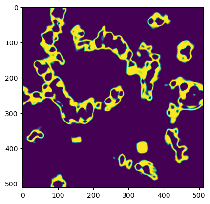

```python
    from skvideo.io import FFmpegWriter
    from matplotlib import cm

    fps = 10
    frames = 100
    w = FFmpegWriter("smoothlife.mp4", inputdict={"-r": str(fps)})
    for i in range(frames):
        frame = cm.viridis(sl.field)
        frame *= 255
        frame = frame.astype("uint8")
        w.writeFrame(frame)
        sl.step()
    w.close()

    # Also, webm output isn't working for me,
    # so I have to manually convert. Ugh
    # ffmpeg -i smoothlife.mp4 -c:v libvpx -b:v 2M smoothlife.webm


if __name__ == "__main__":
    show_animation()
    # save_animation()
```